# 10. Practice - IMDb

## Análise de dados do dataset IMDb

```python
import numpy as np
import pandas as pd
import seaborn as sns
import matplotlib.pyplot as plt
```

```python
%config Completer.use_jedi = False
```

- Carregando os dados

```python
movies = pd.read_csv('datasets/Movie+Assignment+Data.csv')
```

```python
pd.set_option('display.max_columns',70)
```

```python
movies.head()
```

|  | Title | title_year | budget | Gross | actor_1_name | actor_2_name | actor_3_name | actor_1_facebook_likes | actor_2_facebook_likes | actor_3_facebook_likes | IMDb_rating | genre_1 | genre_2 | genre_3 | MetaCritic | Runtime | CVotes10 | CVotes09 | CVotes08 | CVotes07 | CVotes06 | CVotes05 | CVotes04 | CVotes03 | CVotes02 | CVotes01 | CVotesMale | CVotesFemale | CVotesU18 | … |
| --- | --- | --- | --- | --- | --- | --- | --- | --- | --- | --- | --- | --- | --- | --- | --- | --- | --- | --- | --- | --- | --- | --- | --- | --- | --- | --- | --- | --- | --- | --- |
| 0 | La La Land | 2016 | 30000000 | 151101803 | Ryan Gosling | Emma Stone | Amiée Conn | 14000 | 19000.0 | NaN | 8.2 | Comedy | Drama | Music | 93.0 | 128 | 74245 | 71191 | 64640 | 38831 | 17377 | 8044 | 3998 | 2839 | 2407 | 6802 | 157693 | 56713 | 2675 | … |
| 1 | Zootopia | 2016 | 150000000 | 341268248 | Ginnifer Goodwin | Jason Bateman | Idris Elba | 2800 | 28000.0 | 27000.0 | 8.1 | Animation | Adventure | Comedy | 78.0 | 108 | 53626 | 70912 | 102352 | 57261 | 16719 | 4539 | 1467 | 733 | 496 | 1386 | 176202 | 52345 | 2362 | … |
| 2 | Lion | 2016 | 12000000 | 51738905 | Dev Patel | Nicole Kidman | Rooney Mara | 33000 | 96000.0 | 9800.0 | 8.1 | Biography | Drama | NaN | 69.0 | 118 | 23325 | 29830 | 40564 | 20296 | 5842 | 1669 | 558 | 309 | 182 | 493 | 68921 | 24977 | 702 | … |
| 3 | Arrival | 2016 | 47000000 | 100546139 | Amy Adams | Jeremy Renner | Forest Whitaker | 35000 | 5300.0 | NaN | 8.0 | Drama | Mystery | Sci-Fi | 81.0 | 116 | 55533 | 87850 | 109536 | 65440 | 26913 | 10556 | 5057 | 3083 | 2194 | 4734 | 237437 | 46272 | 1943 | … |
| 4 | Manchester by the Sea | 2016 | 9000000 | 47695371 | Casey Affleck | Michelle Williams | Kyle Chandler | 518 | 71000.0 | 3300.0 | 7.9 | Drama | NaN | NaN | 96.0 | 137 | 18191 | 33532 | 46596 | 29626 | 11879 | 4539 | 1976 | 1233 | 888 | 1834 | 92452 | 22834 | 855 | … |

- **Title**: Título do filme
- **title_year**: ano do filme
- **budget**: orçamento do filme em dólar
- **Gross**: rendimento bruto do filme em dólar
- **actor_1_name**: Nome do ator principal do filme
- **actor_2_name**: Nome do segundo ator coadjuvante
- **actor_3_name**: Nome do terceiro ator coadjuvante
- **actor_1_facebook_likes**: Curtidas no facebook do ator principal do filme
- **actor_2_facebook_likes**: Curtidas no facebook do segundo ator coadjuvante do filme
- **actor_3_facebook_likes**: Curtidas no facebook do terceiro ator coadjuvante do filme
- **IMDb_rating**: Notas do filme no IMDb
- **genre_1**: Gênero principal do filme
- **genre_2**: Gênero secundário do filme
- **genre_3**: Gênero terciário do filme
- **MetaCritic**: Avaliação média no Metacritic (website de críticas) em uma escala de 100
- **Runtime**: Duração do filme em minutos
- **CVotes10**: Número de pessoas que votaram 10/10 para o filme
- **CVotes09**: Número de pessoas que votaram 9/10 para o filme
- **CVotes08**: Número de pessoas que votaram 8/10 para o filme
- **CVotes07**: Número de pessoas que votaram 7/10 para o filme
- **CVotes06**: Número de pessoas que votaram 6/10 para o filme
- **CVotes05**: Número de pessoas que votaram 5/10 para o filme
- **CVotes04**: Número de pessoas que votaram 4/10 para o filme
- **CVotes03**: Número de pessoas que votaram 3/10 para o filme
- **Cvotes02**: Número de pessoas que votaram 2/10 para o filme
- **CVotes01**: Número de pessoas que votaram 1/10 para o filme
- **CVotesMale**: Número total de votos dos homens
- **CVotesFemale**: Número total de votos das mulheres
- **CVotesU18**: Número de votos do grupo com idade inferior a 18 anos
- **CVotesU18M**: Número de votos dos homens do grupo com idade inferior a 18 anos
- **CVotesU18F**: Número de votos das mulheres do grupo com idade inferior a 18 anos
- **CVotes1829**: Número de votos do grupo com idade entre 18 e 29 anos
- **CVotes1829M**: Número de votos dos homens do grupo com idade entre 18 e 29 anos
- **CVotes1829F**: Número de votos das mulheres do grupo com idade entre 18 e 29 anos
- **CVotes3044**: Números de votos do grupo com idade entre 30 a 44 anos
- **CVotes3044M**: Números de votos dos homens do grupo com idade entre 30 a 44 anos
- **CVotes3044F**: Números de votos das mulheres do grupo com idade entre 30 a 44 anos
- **CVotes45A**: Número de votos do grupo com idade superior a 45 anos
- **CVotes45AM**: Número de votos dos homens do grupo com idade superior a 45 anos
- **CVotes45AF**: Número de votos das mulheres do grupo com idade superior a 45 anos
- **CVotes1000**: Número de votos dos top 1000 votantes do IMDb
- **CVotesUS**: Número de votos de americanos
- **CVotesnUS**: Número de votos de não-americanos
- **VotesM**: Avaliação média dada por homens
- **VotesF**: Avaliação média dada por mulheres
- **VotesU18**: Avaliação média dada pelo grupo com idade inferior a 18 anos
- **VotesU18M**: Avaliação média dada pelos homens do grupo com idade inferior a 18 anos
- **VotesU18F**: Avaliação média dada pelas mulheres do grupo com idade inferior a 18 anos
- **Votes1829**: Avaliação média dada pelo grupo com idade entre 18 a 29 anos
- **Votes1829M**: Avaliação média dada pelos homens do grupo com idade entre 18 a 29 anos
- **Votes1829F**: Avaliação média dada pelas mulheres do grupo com idade entre 18 a 29 anos
- **Votes3044**: Avaliação média dada pelo grupo com idade entre 30 a 44 anos
- **Votes3044M**: Avaliação média dada pelos homens do grupo com idade entre 30 a 44 anos
- **Votes3044F**: Avaliação média dada pelas mulheres do grupo com idade entre 30 a 44 anos
- **Votes45A**: Avaliação média dada pelo grupo com idade superior a 45 anos
- **Votes45AM**: Avaliação média dada pelos homens do grupo com idade superior a 45 anos
- **Votes45AF**: Avaliação média dada pelas mulheres do grupo com idade superior a 45 anos
- **Votes1000**: Avaliação média dada pelos top 1000 votantes do IMDb
- **VotesUS**: Avaliação média dada pelos americanos
- **VotesnUS**: Avaliação média dada pelos não-americanos
- **content_rating**: Classificação do conteúdo do filme. Por exemplo: PG-13, classificação R, etc.
- **Country**: País de origem do filme
- Vamos inspecionar os dados

```python
movies.shape
```

```
(100, 62)
```

```python
movies.info()
```

```
<class 'pandas.core.frame.DataFrame'>
RangeIndex: 100 entries, 0 to 99
Data columns (total 62 columns):
 #   Column                  Non-Null Count  Dtype
---  ------                  --------------  -----
 0   Title                   100 non-null    object
 1   title_year              100 non-null    int64
 2   budget                  100 non-null    int64
 3   Gross                   100 non-null    int64
 4   actor_1_name            100 non-null    object
 5   actor_2_name            100 non-null    object
 6   actor_3_name            100 non-null    object
 7   actor_1_facebook_likes  100 non-null    int64
 8   actor_2_facebook_likes  99 non-null     float64
 9   actor_3_facebook_likes  98 non-null     float64
```

[output cut: 54 more lines]

```python
movies.describe(include='all')
```

|  | Title | title_year | budget | Gross | actor_1_name | actor_2_name | actor_3_name | actor_1_facebook_likes | actor_2_facebook_likes | actor_3_facebook_likes | IMDb_rating | genre_1 | genre_2 | genre_3 | MetaCritic | Runtime | CVotes10 | CVotes09 | CVotes08 | CVotes07 | CVotes06 | CVotes05 | CVotes04 | CVotes03 | CVotes02 | CVotes01 | CVotesMale | CVotesFemale | CVotesU18 | … |
| --- | --- | --- | --- | --- | --- | --- | --- | --- | --- | --- | --- | --- | --- | --- | --- | --- | --- | --- | --- | --- | --- | --- | --- | --- | --- | --- | --- | --- | --- | --- |
| count | 100 | 100.000000 | 1.000000e+02 | 1.000000e+02 | 100 | 100 | 100 | 100.000000 | 99.000000 | 98.000000 | 100.000000 | 100 | 97 | 74 | 95.000000 | 100.000000 | 100.000000 | 100.000000 | 100.000000 | 100.000000 | 100.000000 | 100.000000 | 100.000000 | 100.000000 | 100.000000 | 100.000000 | 1.000000e+02 | 100.000000 | 100.000000 | … |
| unique | 100 | NaN | NaN | NaN | 75 | 94 | 96 | NaN | NaN | NaN | NaN | 8 | 19 | 15 | NaN | NaN | NaN | NaN | NaN | NaN | NaN | NaN | NaN | NaN | NaN | NaN | NaN | NaN | NaN | … |
| top | La La Land | NaN | NaN | NaN | Leonardo DiCaprio | Jeff Bridges | James Nesbitt | NaN | NaN | NaN | NaN | Action | Drama | Sci-Fi | NaN | NaN | NaN | NaN | NaN | NaN | NaN | NaN | NaN | NaN | NaN | NaN | NaN | NaN | NaN | … |
| freq | 1 | NaN | NaN | NaN | 5 | 2 | 2 | NaN | NaN | NaN | NaN | 27 | 35 | 15 | NaN | NaN | NaN | NaN | NaN | NaN | NaN | NaN | NaN | NaN | NaN | NaN | NaN | NaN | NaN | … |
| mean | NaN | 2012.820000 | 7.838400e+07 | 1.468679e+08 | NaN | NaN | NaN | 13407.270000 | 7377.303030 | 3002.153061 | 7.883000 | NaN | NaN | NaN | 78.252632 | 126.420000 | 73212.160000 | 92404.170000 | 125762.230000 | 76715.280000 | 27841.450000 | 10171.750000 | 4330.110000 | 2477.070000 | 1711.570000 | 4084.350000 | 2.714462e+05 | 64468.860000 | 1769.050000 | … |
| std | NaN | 1.919491 | 7.445295e+07 | 1.454004e+08 | NaN | NaN | NaN | 10649.037862 | 13471.568216 | 6940.301133 | 0.247433 | NaN | NaN | NaN | 9.122066 | 19.050799 | 82669.594746 | 75666.918775 | 62162.752481 | 32586.358624 | 12883.912563 | 5480.914204 | 2713.608902 | 1768.167506 | 1318.631164 | 3489.778403 | 1.676580e+05 | 39117.954828 | 1324.522818 | … |
| min | NaN | 2010.000000 | 3.000000e+06 | 2.238380e+05 | NaN | NaN | NaN | 39.000000 | 12.000000 | 0.000000 | 7.500000 | NaN | NaN | NaN | 62.000000 | 91.000000 | 6420.000000 | 7321.000000 | 11668.000000 | 8558.000000 | 3370.000000 | 1162.000000 | 456.000000 | 227.000000 | 158.000000 | 293.000000 | 2.244100e+04 | 9552.000000 | 121.000000 | … |
| 25% | NaN | 2011.000000 | 1.575000e+07 | 4.199752e+07 | NaN | NaN | NaN | 1000.000000 | 580.000000 | 319.750000 | 7.700000 | NaN | NaN | NaN | 72.000000 | 114.750000 | 30587.000000 | 47098.250000 | 83207.500000 | 54934.500000 | 17834.500000 | 6026.000000 | 2293.500000 | 1172.750000 | 761.750000 | 1532.750000 | 1.719362e+05 | 35188.750000 | 756.250000 | … |
| 50% | NaN | 2013.000000 | 4.225000e+07 | 1.070266e+08 | NaN | NaN | NaN | 13000.000000 | 1000.000000 | 626.500000 | 7.800000 | NaN | NaN | NaN | 78.000000 | 124.000000 | 54900.500000 | 71376.000000 | 117405.500000 | 76862.000000 | 27072.000000 | 9123.000000 | 3801.000000 | 1950.000000 | 1320.000000 | 2933.000000 | 2.381995e+05 | 58539.500000 | 1420.000000 | … |
| 75% | NaN | 2014.000000 | 1.500000e+08 | 2.107548e+08 | NaN | NaN | NaN | 20000.000000 | 11000.000000 | 1000.000000 | 8.100000 | NaN | NaN | NaN | 83.500000 | 136.250000 | 80639.000000 | 115240.250000 | 166742.500000 | 100789.000000 | 37561.750000 | 13008.500000 | 5571.000000 | 3309.500000 | 2334.500000 | 5296.000000 | 3.383265e+05 | 82355.000000 | 2478.750000 | … |
| max | NaN | 2016.000000 | 2.600000e+08 | 9.366622e+08 | NaN | NaN | NaN | 35000.000000 | 96000.000000 | 46000.000000 | 8.800000 | NaN | NaN | NaN | 100.000000 | 180.000000 | 584839.000000 | 485218.000000 | 304457.000000 | 162604.000000 | 67579.000000 | 27957.000000 | 12286.000000 | 7868.000000 | 5751.000000 | 15768.000000 | 1.044318e+06 | 239796.000000 | 5735.000000 | … |

### Quais são os que filmes mais deram lucro?

- Para responder essa pergunta nós vamos analisar
  - os atributos do filme
  - o orçamento do filme
  - o lucro de cada filme
- Os números de orçamento (*budget*) e rendimento (*lucro*) são muito grande.
- Para melhorar a leitura, vamos converter a unidade do orçamento e rendimento para milhão.

```python
movies['Gross']=movies['Gross'].floordiv(1000000)
```

```python
movies['budget']=movies['budget'].floordiv(1000000)
```

- Vamos criar uma nova coluna chamada *Profit* (lucro) para armazenar a diferença entre as colunas de rendimento e orçamento.

```python
movies.insert(4, column='Profit', value=movies['Gross']-movies['budget'])
```

- Agora vamos ordenar o *dataframe* usando a coluna lucro como referência para identificar os 10 filmes que mais deram lucro

```python
movies.sort_values(by=['Profit'], ascending=False, inplace=True, ignore_index=True)

top_10=movies.loc[0:9, 'Title']
top_10
```

```
0    Star Wars: Episode VII - The Force Awakens
1                                  The Avengers
2                                      Deadpool
3               The Hunger Games: Catching Fire
4                                   Toy Story 3
5                         The Dark Knight Rises
6                                The Lego Movie
7                                      Zootopia
8                                 Despicable Me
9                                    Inside Out
Name: Title, dtype: object
```

### Há alguma correlação entre o valores do custo e do lucro?

- Vamos plotar um scatter para correlacionar as colunas de orçamento e lucro

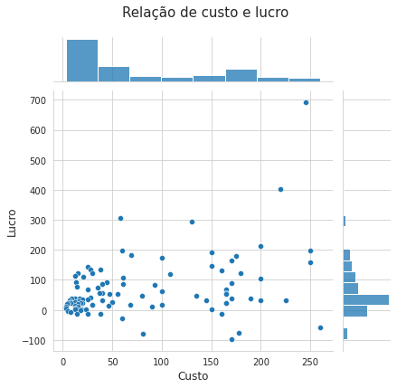

```python
sns.set_style('whitegrid')

plt.figure(figsize=[8,6])
h=sns.jointplot(x='budget', y='Profit', data=movies)
h.set_axis_labels('Custo', 'Lucro', fontsize=12)
plt.subplots_adjust(top=0.9)
plt.suptitle('Relação de custo e lucro', fontsize=15)
plt.show()
```

- Podemos obsevar que a maioria dos filmes estão no canto inferior esquerdo
- Alguns filmes tiveram valores de orçamento alto, mas ainda sim tiveram um lucro negativo
- Podemos notar também que uma suave correlação positiva entre o valor do orçamento e o lucro

### Quais são os filmes que mais deram prejuízo?

- Vamos verificar os filmes que tiveram prejuízo

```python
negative_profit=movies[movies['Profit'] < 0]
negative_profit.reset_index(drop=True)

negative_profit.sort_values(by='Profit')[0:5]
```

|  | Title | title_year | budget | Gross | Profit | actor_1_name | actor_2_name | actor_3_name | actor_1_facebook_likes | actor_2_facebook_likes | actor_3_facebook_likes | IMDb_rating | genre_1 | genre_2 | genre_3 | MetaCritic | Runtime | CVotes10 | CVotes09 | CVotes08 | CVotes07 | CVotes06 | CVotes05 | CVotes04 | CVotes03 | CVotes02 | CVotes01 | CVotesMale | CVotesFemale | … |
| --- | --- | --- | --- | --- | --- | --- | --- | --- | --- | --- | --- | --- | --- | --- | --- | --- | --- | --- | --- | --- | --- | --- | --- | --- | --- | --- | --- | --- | --- | --- |
| 99 | Hugo | 2011 | 170 | 73 | -97 | ChloÃ« Grace Moretz | Christopher Lee | Ray Winstone | 17000 | 16000.0 | 1000.0 | 7.5 | Adventure | Drama | Family | 83.0 | 126 | 29228 | 40728 | 77893 | 62936 | 27932 | 11179 | 4664 | 2674 | 1700 | 3023 | 179655 | 47795 | … |
| 98 | The Little Prince | 2015 | 81 | 1 | -80 | Jeff Bridges | James Franco | Mackenzie Foy | 12000 | 11000.0 | 6000.0 | 7.8 | Animation | Adventure | Drama | 70.0 | 108 | 7565 | 7321 | 11668 | 8558 | 3370 | 1162 | 456 | 227 | 158 | 293 | 22441 | 9552 | … |
| 97 | Edge of Tomorrow | 2014 | 178 | 100 | -78 | Tom Cruise | Lara Pulver | Noah Taylor | 10000 | 854.0 | 509.0 | 7.9 | Action | Adventure | Sci-Fi | 71.0 | 113 | 60383 | 99596 | 175961 | 100724 | 28982 | 8145 | 2858 | 1368 | 857 | 1661 | 341199 | 45790 | … |
| 96 | Tangled | 2010 | 260 | 200 | -60 | Brad Garrett | Donna Murphy | M.C. Gainey | 799 | 553.0 | 284.0 | 7.8 | Animation | Adventure | Comedy | 71.0 | 124 | 56575 | 54688 | 97207 | 70947 | 26805 | 8530 | 3043 | 1396 | 805 | 1606 | 166088 | 97213 | … |
| 95 | Scott Pilgrim vs. the World | 2010 | 60 | 31 | -29 | Anna Kendrick | Kieran Culkin | Ellen Wong | 10000 | 1000.0 | 719.0 | 7.5 | Action | Comedy | Romance | 69.0 | 112 | 47292 | 48976 | 79198 | 59689 | 28452 | 13451 | 6977 | 4254 | 3069 | 6287 | 208417 | 45718 | … |

### Quais os filmes mais populares, ou seja, que tiveram uma boa resposta do público?

- Para isso podemos utilizar as colunas *MetaCritic* e a *IMDb_rating*.
- Contudo é necessário converter ambas as colunas para os valores ficarem na mesma escala. A coluna *MetaCritic* está numa escala de 100 e a *IMDb_rating* está em uma escala de 10.

```python
movies['MetaCritic'] = movies['MetaCritic']/10
```

- Vamos criar uma coluna para armazenar o valor médio de ambas os valores da crítica.

```python
movies.insert(18, column='Avg_rating', value=movies.loc[:, ['MetaCritic', 'IMDb_rating']].mean(axis=1))
```

```python
movies.sort_values(by='Avg_rating', ascending=False, inplace=True)
```

- Agora nós temos todos os filmes ordenados pela sua popularidade

```python
movies.head()
```

|  | Title | title_year | budget | Gross | Profit | actor_1_name | actor_2_name | actor_3_name | actor_1_facebook_likes | actor_2_facebook_likes | actor_3_facebook_likes | IMDb_rating | genre_1 | genre_2 | genre_3 | MetaCritic | Runtime | CVotes10 | Avg_rating | CVotes09 | CVotes08 | CVotes07 | CVotes06 | CVotes05 | CVotes04 | CVotes03 | CVotes02 | CVotes01 | CVotesMale | … |
| --- | --- | --- | --- | --- | --- | --- | --- | --- | --- | --- | --- | --- | --- | --- | --- | --- | --- | --- | --- | --- | --- | --- | --- | --- | --- | --- | --- | --- | --- | --- |
| 69 | Boyhood | 2014 | 4 | 25 | 21 | Ellar Coltrane | Lorelei Linklater | Libby Villari | 230 | 193.0 | 127.0 | 7.9 | Drama | NaN | NaN | 10.0 | 165 | 49673 | 8.95 | 62055 | 76838 | 52238 | 23789 | 10431 | 4906 | 3071 | 2248 | 5086 | 183807 | … |
| 51 | 12 Years a Slave | 2013 | 20 | 56 | 36 | QuvenzhanÃ© Wallis | Scoot McNairy | Taran Killam | 2000 | 660.0 | 500.0 | 8.1 | Biography | Drama | History | 9.6 | 134 | 75556 | 8.85 | 126223 | 161460 | 83070 | 27231 | 9603 | 4021 | 2420 | 1785 | 4739 | 313823 | … |
| 9 | Inside Out | 2015 | 175 | 356 | 181 | Amy Poehler | Mindy Kaling | Phyllis Smith | 1000 | 767.0 | 384.0 | 8.2 | Animation | Adventure | Comedy | 9.4 | 95 | 87509 | 8.80 | 113244 | 119801 | 67153 | 24210 | 8542 | 3349 | 1872 | 1123 | 3450 | 244433 | … |
| 20 | La La Land | 2016 | 30 | 151 | 121 | Ryan Gosling | Emma Stone | Amiée Conn | 14000 | 19000.0 | NaN | 8.2 | Comedy | Drama | Music | 9.3 | 128 | 74245 | 8.75 | 71191 | 64640 | 38831 | 17377 | 8044 | 3998 | 2839 | 2407 | 6802 | 157693 | … |
| 49 | Manchester by the Sea | 2016 | 9 | 47 | 38 | Casey Affleck | Michelle Williams | Kyle Chandler | 518 | 71000.0 | 3300.0 | 7.9 | Drama | NaN | NaN | 9.6 | 137 | 18191 | 8.75 | 33532 | 46596 | 29626 | 11879 | 4539 | 1976 | 1233 | 888 | 1834 | 92452 | … |

- Podemos utilizar outro critério, como por exemplo, os filmes que tiveram valores alto em ambas as colunas de *IMDb_rating* e *MetaCritic*, ou seja que tiveram a crítica mais consistente

```python
# Pegando os filmes que tiveram uma diferença absoluta menor que 0.5
UniversalAcclaim = movies[abs(movies['MetaCritic'] - movies['IMDb_rating']) < 0.5]

# Selecionando os filmes com uma diferença absoluta menor que 0.5 e média de pontuação maior que 8
UniversalAcclaim[(abs(movies['MetaCritic']-movies['IMDb_rating']) < 0.5) & (movies['Avg_rating'] >= 8)].sort_index()[0:5]
```

|  | Title | title_year | budget | Gross | Profit | actor_1_name | actor_2_name | actor_3_name | actor_1_facebook_likes | actor_2_facebook_likes | actor_3_facebook_likes | IMDb_rating | genre_1 | genre_2 | genre_3 | MetaCritic | Runtime | CVotes10 | Avg_rating | CVotes09 | CVotes08 | CVotes07 | CVotes06 | CVotes05 | CVotes04 | CVotes03 | CVotes02 | CVotes01 | CVotesMale | … |
| --- | --- | --- | --- | --- | --- | --- | --- | --- | --- | --- | --- | --- | --- | --- | --- | --- | --- | --- | --- | --- | --- | --- | --- | --- | --- | --- | --- | --- | --- | --- |
| 0 | Star Wars: Episode VII - The Force Awakens | 2015 | 245 | 936 | 691 | Doug Walker | Rob Walker | 0 | 131 | 12.0 | 0.0 | 8.1 | Action | Adventure | Fantasy | 8.1 | 136 | 155391 | 8.10 | 161810 | 166378 | 99402 | 40734 | 18060 | 8751 | 5970 | 4489 | 15768 | 425971 | … |
| 21 | The Martian | 2015 | 108 | 228 | 120 | Matt Damon | Donald Glover | Benedict Wong | 13000 | 801.0 | 372.0 | 8.0 | Adventure | Drama | Sci-Fi | 8.0 | 144 | 75560 | 8.00 | 139593 | 200315 | 102723 | 31179 | 9930 | 3815 | 2046 | 1316 | 2907 | 359265 | … |
| 24 | Gone Girl | 2014 | 61 | 167 | 106 | Patrick Fugit | Sela Ward | Emily Ratajkowski | 835 | 812.0 | 625.0 | 8.1 | Crime | Drama | Mystery | 7.9 | 149 | 89539 | 8.00 | 177373 | 218018 | 103600 | 32989 | 11691 | 5285 | 3262 | 2247 | 5500 | 397571 | … |
| 36 | Django Unchained | 2012 | 100 | 162 | 62 | Leonardo DiCaprio | Christoph Waltz | Ato Essandoh | 29000 | 11000.0 | 265.0 | 8.4 | Drama | Western | NaN | 8.1 | 165 | 234824 | 8.25 | 339329 | 286911 | 121445 | 38251 | 14227 | 6469 | 4149 | 3181 | 8065 | 695211 | … |
| 40 | Arrival | 2016 | 47 | 100 | 53 | Amy Adams | Jeremy Renner | Forest Whitaker | 35000 | 5300.0 | NaN | 8.0 | Drama | Mystery | Sci-Fi | 8.1 | 116 | 55533 | 8.05 | 87850 | 109536 | 65440 | 26913 | 10556 | 5057 | 3083 | 2194 | 4734 | 237437 | … |

- Ainda com os filmes do conjunto de dados com valores consistentes vamos ordená-los pelos filmes que tiveram maior média de crítica

```python
UniversalAcclaim.sort_values(by='Avg_rating', ascending=False, inplace=True)
UniversalAcclaim.reset_index(drop=True, inplace=True)
UniversalAcclaim[0:5]
```

|  | Title | title_year | budget | Gross | Profit | actor_1_name | actor_2_name | actor_3_name | actor_1_facebook_likes | actor_2_facebook_likes | actor_3_facebook_likes | IMDb_rating | genre_1 | genre_2 | genre_3 | MetaCritic | Runtime | CVotes10 | Avg_rating | CVotes09 | CVotes08 | CVotes07 | CVotes06 | CVotes05 | CVotes04 | CVotes03 | CVotes02 | CVotes01 | CVotesMale | … |
| --- | --- | --- | --- | --- | --- | --- | --- | --- | --- | --- | --- | --- | --- | --- | --- | --- | --- | --- | --- | --- | --- | --- | --- | --- | --- | --- | --- | --- | --- | --- |
| 0 | Whiplash | 2014 | 3 | 13 | 10 | J.K. Simmons | Melissa Benoist | Chris Mulkey | 24000 | 970.0 | 535.0 | 8.5 | Drama | Music | NaN | 8.8 | 107 | 110404 | 8.65 | 161864 | 132656 | 56007 | 16577 | 6031 | 2937 | 1859 | 1263 | 2723 | 308900 | … |
| 1 | Django Unchained | 2012 | 100 | 162 | 62 | Leonardo DiCaprio | Christoph Waltz | Ato Essandoh | 29000 | 11000.0 | 265.0 | 8.4 | Drama | Western | NaN | 8.1 | 165 | 234824 | 8.25 | 339329 | 286911 | 121445 | 38251 | 14227 | 6469 | 4149 | 3181 | 8065 | 695211 | … |
| 2 | Dallas Buyers Club | 2013 | 5 | 27 | 22 | Matthew McConaughey | Jennifer Garner | Denis O'Hare | 11000 | 3000.0 | 896.0 | 8.0 | Biography | Drama | NaN | 8.4 | 117 | 37544 | 8.20 | 82276 | 145488 | 66156 | 16777 | 4582 | 1721 | 870 | 654 | 1588 | 231258 | … |
| 3 | Star Wars: Episode VII - The Force Awakens | 2015 | 245 | 936 | 691 | Doug Walker | Rob Walker | 0 | 131 | 12.0 | 0.0 | 8.1 | Action | Adventure | Fantasy | 8.1 | 136 | 155391 | 8.10 | 161810 | 166378 | 99402 | 40734 | 18060 | 8751 | 5970 | 4489 | 15768 | 425971 | … |
| 4 | Arrival | 2016 | 47 | 100 | 53 | Amy Adams | Jeremy Renner | Forest Whitaker | 35000 | 5300.0 | NaN | 8.0 | Drama | Mystery | Sci-Fi | 8.1 | 116 | 55533 | 8.05 | 87850 | 109536 | 65440 | 26913 | 10556 | 5057 | 3083 | 2194 | 4734 | 237437 | … |

### Quais elencos tiveram mais popularidade combinado?

- Agora vamos identificar os top5 trio de atores que tiveram mais popularidade combinado, para isso vamos utilizar como métrica os *likes* do *Facebook*

```python
movies.insert(11, column='Popularity', value=movies.loc[:,['actor_1_facebook_likes',
                                                           'actor_2_facebook_likes',
                                                           'actor_3_facebook_likes']].sum(axis=1))
```

```python
top_popular_actors=movies.sort_values(by='Popularity', ascending=False, ignore_index=True).loc[0:4,:]
top_popular_actors
```

|  | Title | title_year | budget | Gross | Profit | actor_1_name | actor_2_name | actor_3_name | actor_1_facebook_likes | actor_2_facebook_likes | actor_3_facebook_likes | Popularity | IMDb_rating | genre_1 | genre_2 | genre_3 | MetaCritic | Runtime | CVotes10 | Avg_rating | CVotes09 | CVotes08 | CVotes07 | CVotes06 | CVotes05 | CVotes04 | CVotes03 | CVotes02 | CVotes01 | … |
| --- | --- | --- | --- | --- | --- | --- | --- | --- | --- | --- | --- | --- | --- | --- | --- | --- | --- | --- | --- | --- | --- | --- | --- | --- | --- | --- | --- | --- | --- | --- |
| 0 | Lion | 2016 | 12 | 51 | 39 | Dev Patel | Nicole Kidman | Rooney Mara | 33000 | 96000.0 | 9800.0 | 138800.0 | 8.1 | Biography | Drama | NaN | 6.9 | 118 | 23325 | 7.50 | 29830 | 40564 | 20296 | 5842 | 1669 | 558 | 309 | 182 | 493 | … |
| 1 | Inception | 2010 | 160 | 292 | 132 | Leonardo DiCaprio | Tom Hardy | Joseph Gordon-Levitt | 29000 | 27000.0 | 23000.0 | 79000.0 | 8.8 | Action | Adventure | Sci-Fi | 7.4 | 148 | 584839 | 8.10 | 485218 | 304457 | 130972 | 46393 | 20595 | 10050 | 6631 | 5243 | 15365 | … |
| 2 | X-Men: Days of Future Past | 2014 | 200 | 233 | 33 | Jennifer Lawrence | Peter Dinklage | Hugh Jackman | 34000 | 22000.0 | 20000.0 | 76000.0 | 8.0 | Action | Adventure | Sci-Fi | 7.4 | 132 | 91765 | 7.70 | 127521 | 183578 | 104658 | 33027 | 10059 | 3710 | 1903 | 1225 | 3301 | … |
| 3 | Manchester by the Sea | 2016 | 9 | 47 | 38 | Casey Affleck | Michelle Williams | Kyle Chandler | 518 | 71000.0 | 3300.0 | 74818.0 | 7.9 | Drama | NaN | NaN | 9.6 | 137 | 18191 | 8.75 | 33532 | 46596 | 29626 | 11879 | 4539 | 1976 | 1233 | 888 | 1834 | … |
| 4 | The Dark Knight Rises | 2012 | 250 | 448 | 198 | Tom Hardy | Christian Bale | Joseph Gordon-Levitt | 27000 | 23000.0 | 23000.0 | 73000.0 | 8.4 | Action | Thriller | NaN | 7.8 | 164 | 380589 | 8.10 | 341965 | 281426 | 134959 | 50406 | 20106 | 9589 | 5713 | 4073 | 11988 | … |

```python
top_5_popular_trios=movies.sort_values(by='Popularity', ascending=False,
                                      ignore_index=True).loc[0:4, ['actor_1_name', 'actor_2_name', 'actor_3_name']].values.tolist()

top_5_popular_trios
```

```
[['Dev Patel', 'Nicole Kidman', 'Rooney Mara'],
 ['Leonardo DiCaprio', 'Tom Hardy', 'Joseph Gordon-Levitt'],
 ['Jennifer Lawrence', 'Peter Dinklage', 'Hugh Jackman'],
 ['Casey Affleck', 'Michelle Williams ', 'Kyle Chandler'],
 ['Tom Hardy', 'Christian Bale', 'Joseph Gordon-Levitt']]
```

### Qual a faixa de duração que a maioria dos filmes possuem?

- Vamos verificar a distribuição de filmes pela sua duração em minutos

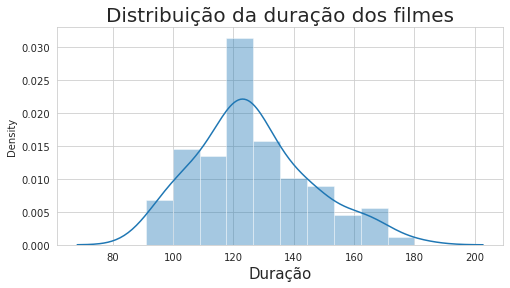

```python
plt.figure(figsize=[8,4])
run=sns.distplot(movies['Runtime'])
run.axes.set_title('Distribuição da duração dos filmes', fontsize=20)
run.set_xlabel("Duração", fontsize=15)
plt.show()
```

### Quais são os filmes de classificação R mais populares entre os jovens com menos de 18 anos?

- Vamos aprofundar nossa análise nos filmes de classificação R de conteúdo, ou seja, os filmes que são restritos para menores de 18 anos.
- Depois ordená-los pelo número de votos do grupo com idade inferior a 18 anos (*CVotesU18*) em ordem decrescente e verificar os top5.

```python
content_r = movies[movies['content_rating']=='R']
PopularR = content_r.sort_values(by='CVotesU18', ascending = False, ignore_index=True)[0:10]
PopularR[0:5]
```

|  | Title | title_year | budget | Gross | Profit | actor_1_name | actor_2_name | actor_3_name | actor_1_facebook_likes | actor_2_facebook_likes | actor_3_facebook_likes | Popularity | IMDb_rating | genre_1 | genre_2 | genre_3 | MetaCritic | Runtime | CVotes10 | Avg_rating | CVotes09 | CVotes08 | CVotes07 | CVotes06 | CVotes05 | CVotes04 | CVotes03 | CVotes02 | CVotes01 | … |
| --- | --- | --- | --- | --- | --- | --- | --- | --- | --- | --- | --- | --- | --- | --- | --- | --- | --- | --- | --- | --- | --- | --- | --- | --- | --- | --- | --- | --- | --- | --- |
| 0 | Deadpool | 2016 | 58 | 363 | 305 | Ryan Reynolds | Ed Skrein | Stefan Kapicic | 16000 | 805.0 | 361.0 | 17166.0 | 8.0 | Action | Adventure | Comedy | 6.5 | 108 | 147467 | 7.25 | 147966 | 170810 | 105717 | 41811 | 15510 | 7046 | 4273 | 3037 | 8538 | … |
| 1 | The Wolf of Wall Street | 2013 | 100 | 116 | 16 | Leonardo DiCaprio | Matthew McConaughey | Jon Favreau | 29000 | 11000.0 | 4000.0 | 44000.0 | 8.2 | Biography | Comedy | Crime | 7.5 | 180 | 171660 | 7.85 | 236650 | 250667 | 129164 | 46715 | 18682 | 8674 | 5854 | 4258 | 9689 | … |
| 2 | Django Unchained | 2012 | 100 | 162 | 62 | Leonardo DiCaprio | Christoph Waltz | Ato Essandoh | 29000 | 11000.0 | 265.0 | 40265.0 | 8.4 | Drama | Western | NaN | 8.1 | 165 | 234824 | 8.25 | 339329 | 286911 | 121445 | 38251 | 14227 | 6469 | 4149 | 3181 | 8065 | … |
| 3 | Mad Max: Fury Road | 2015 | 150 | 153 | 3 | Tom Hardy | Charlize Theron | ZoÃ« Kravitz | 27000 | 9000.0 | 943.0 | 36943.0 | 8.1 | Action | Adventure | Sci-Fi | 9.0 | 120 | 136194 | 8.55 | 158403 | 163494 | 97218 | 42636 | 19505 | 9932 | 6743 | 4930 | 10516 | … |
| 4 | Whiplash | 2014 | 3 | 13 | 10 | J.K. Simmons | Melissa Benoist | Chris Mulkey | 24000 | 970.0 | 535.0 | 25505.0 | 8.5 | Drama | Music | NaN | 8.8 | 107 | 110404 | 8.65 | 161864 | 132656 | 56007 | 16577 | 6031 | 2937 | 1859 | 1263 | 2723 | … |

- *Deadpool*, *The Wolf of Wall Street* são os mais populares entre os jovens.